# Eve: running models

Vera Vinken

2024-10-08

## Load packages

If you get any issues here, try and install the packages manually in the “packages” tab in the right bottom corner.

## Background

TBC

## Set working directories & Load sourcefiles

```r
# Tell R where you are running this from
# Check the output to make sure this is wehre you keep the "Eve" folder
here::i_am("Run_models.Rmd")
print(here())
```

```
## [1] "C:/Local_R/BiPhD-ABM/Eve"
```

```r
# Set directories
  # # Where are the sourcefiles located? (make sure these are global)
  sourcefile_wd<<- paste0(here(), "/Source_files")
  # Specify the parent folder where you want to save results
  saving_wd<<-paste0(here(), "/save_results")

# Load the sourcefiles
  setwd(sourcefile_wd)
  source('MOD_1_FuncSource.R')
  source('ModelSource.R')
```

## Set input variables

```r
num_birds<-100     # default = 1000
daylight_h<-8       # default = 8 hours
days<-10            # default = 30 days
env<-6              # default = environment 6
```

## Run model 1.1: non-hoarding, SC, 1 threshold, 1 variable

```r
#################################################################
##   Model 1.1: Non-hoarding bird, Access to Stomach Content   ##
#################################################################

  # Run the model (This can take a while)
  mod_1_1(days=days, N=num_birds, env_type = env, th_forage_sc = 0.008 , daylight_h = daylight_h)

  # A bunch of things will pop up in your  environment

  # First put together some relevant dataframes (we want both individual data and mean data)
      # total_vars_df11 will have the mean value of each of the 17 variables for each timestep (averaged across alive birds)
      # output_df_list_raw11 is a list with 17 matrices (one for each variable). Matrices are of size Num_birds x timesteps

# list these two
  save_11_list<-list(total_vars_df11, output_df_list_raw11)
  # save the data
  setwd(paste(saving_wd))
  save(save_11_list, file=paste0(format(Sys.time(), "%Y-%m-%d_%H_%M_%S"),'_mod_run11',
                                 'd', days, 'N', num_birds,'env_t', env, 'th_sc', th_forage_sc,
                                 'dayh', daylight_h,'.Rda'
                                 )
       )
# Now you have an Rda object with all the relevant data from your model run.
# It will be marked with the input parameters as well as a time stamp so you can find it and use later :)
```

## Plots for model 1.1: non-hoarding SC, 1 threshold, 1 variable

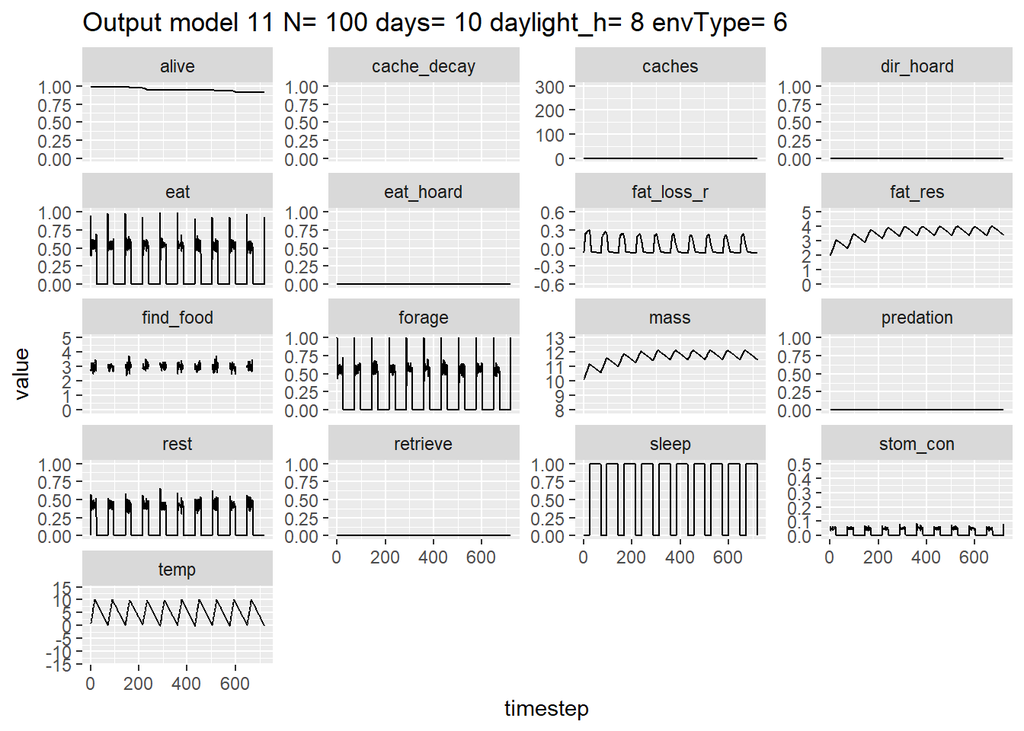

```r
# create plots (standard plots)
plots_12_func(inputdata=save_11_list[[1]], modelType='11')
# if needed
plot_12_11
```

## Run model 1.2: hoarding, SC, 2 thresholds, 1 variable

```r
#################################################################
##   Model 1.2: Non-hoarding bird, Access to Stomach Content   ##
#################################################################

  # Run the model (This can take a while)
  mod_1_2(days=days, N=num_birds, env_type = env, th_forage_sc1=0.0244898, th_forage_sc2=0.03265306 , daylight_h = daylight_h)



# list these two
  save_12_list<-list(total_vars_df12, output_df_list_raw12)
  # save the data
  setwd(paste(saving_wd))
  save(save_12_list, file=paste0(format(Sys.time(), "%Y-%m-%d_%H_%M_%S"),'_mod_run12',
                                 'd', days, 'N', N,'env_t', env_type, 'th_sc1', th_forage_sc1,
                                 'th_sc2', th_forage_sc2, 'dayh', daylight_h,   '.Rda'))
# Now you have an Rda object with all the relevant data from your model run.
# It will be marked with the input parameters as well as a time stamp so you can find it and use later :)
```

## Plots for model 1.2: hoarding SC, 2 thresholds, 1 variable

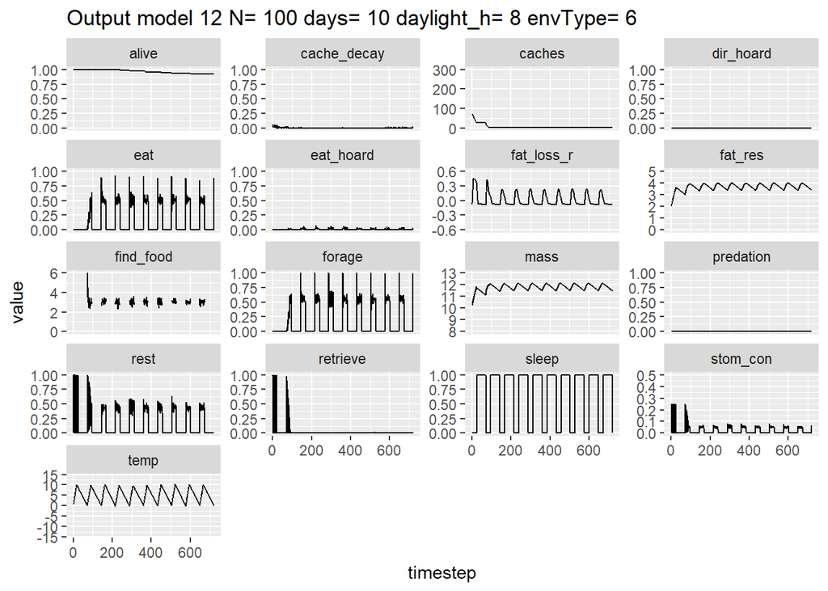

```r
# create plots (standard plots)
plots_12_func(inputdata=save_12_list[[1]], modelType='12')
# if needed
plot_12_12
```

## Run model 2.1: non-hoarding, FR, 1 threshold, 1 variable

```r
#################################################################
##   Model 2.1: Non-hoarding bird, Access to Fat reserve  ##
#################################################################

  # Run the model (This can take a while)
  mod_2_1(days=days, N=num_birds, env_type = env, th_forage_fr = 1.714286 , daylight_h = daylight_h)

# list these two
    save_21_list<-list(total_vars_df21, output_df_list_raw21)
  # save the data
  setwd(paste(saving_wd))
  save(save_21_list, file=paste0(format(Sys.time(), "%Y-%m-%d_%H_%M_%S"),'_mod_run21',
                                 'd', days, 'N', N,'env_t', env_type, 'th_fr', th_forage_fr,
                                 'dayh', daylight_h,   '.Rda'))
# Now you have an Rda object with all the relevant data from your model run.
# It will be marked with the input parameters as well as a time stamp so you can find it and use later :)
```

## Plots for model 2.1: non-hoarding FR, 1 threshold, 1 variable

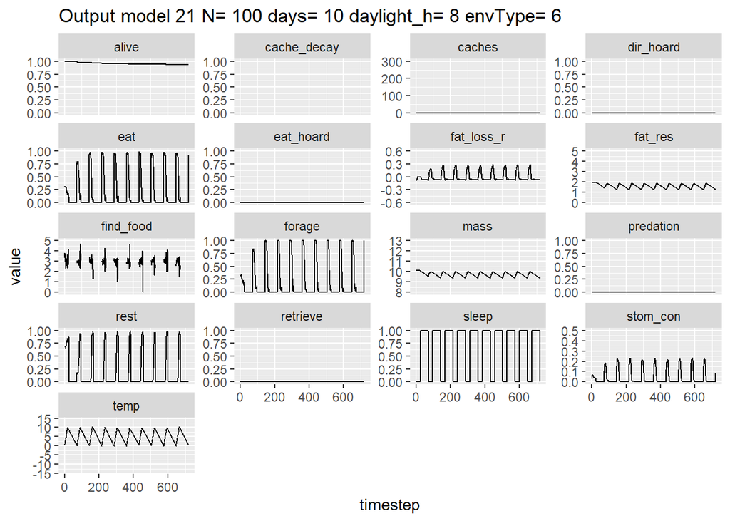

```r
# create plots (standard plots)
plots_12_func(inputdata=save_21_list[[1]], modelType='21')
# if needed
plot_12_21
```

## Run model 2.2: hoarding, FR, 2 thresholds, 1 variable

```r
#################################################################
##   Model 1.2: Non-hoarding bird, Access to Stomach Content   ##
#################################################################

  # Run the model (This can take a while)
  mod_2_2(days=days, N=num_birds, env_type = env, th_forage_fr1=0.6530612, th_forage_fr2= 1.142857, daylight_h = daylight_h)

# list these two
  save_22_list<-list(total_vars_df22, output_df_list_raw22)
  # save the data
  setwd(paste(saving_wd))
  save(save_22_list, file=paste0(format(Sys.time(), "%Y-%m-%d_%H_%M_%S"),'_mod_run22',
                                 'd', days, 'N', N,'env_t', env_type, 'th_fr1', th_forage_fr1,
                                 'th_fr2', th_forage_fr2, 'dayh', daylight_h,   '.Rda'))
# Now you have an Rda object with all the relevant data from your model run.
# It will be marked with the input parameters as well as a time stamp so you can find it and use later :)
```

## Plots for model 2.2: hoarding FR, 2 thresholds, 1 variable

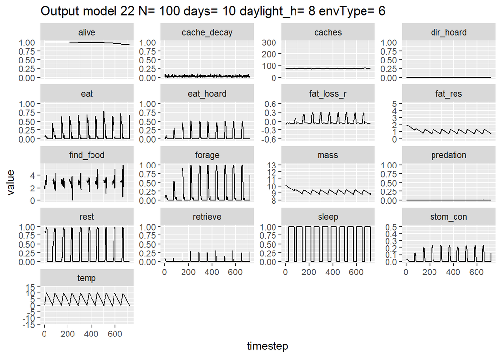

```r
# create plots (standard plots)
plots_12_func(inputdata=save_22_list[[1]], modelType='22')
# if needed
plot_12_22
```

## Run model 3.1: non-hoarding, FLR, 1 threshold, 1 variable

```r
#################################################################
##   Model 3.1: Non-hoarding bird, Access to FLR               ##
#################################################################

  # Run the model (This can take a while)
  mod_3_1(days=days, N=num_birds, env_type = env, th_forage_flr = 0.008 , daylight_h = daylight_h)


# list these two
  save_31_list<-list(total_vars_df31, output_df_list_raw31)
  # save the data
  setwd(paste(saving_wd))
  save(save_31_list, file=paste0(format(Sys.time(), "%Y-%m-%d_%H_%M_%S"),'_mod_run31',
                                 'd', days, 'N', num_birds,'env_t', env, 'th_flr', th_forage_flr,
                                 'dayh', daylight_h,'.Rda'
                                 )
       )
# Now you have an Rda object with all the relevant data from your model run.
# It will be marked with the input parameters as well as a time stamp so you can find it and use later :)
```

## Plots for model 3.1: non-hoarding FLR, 1 threshold, 1 variable

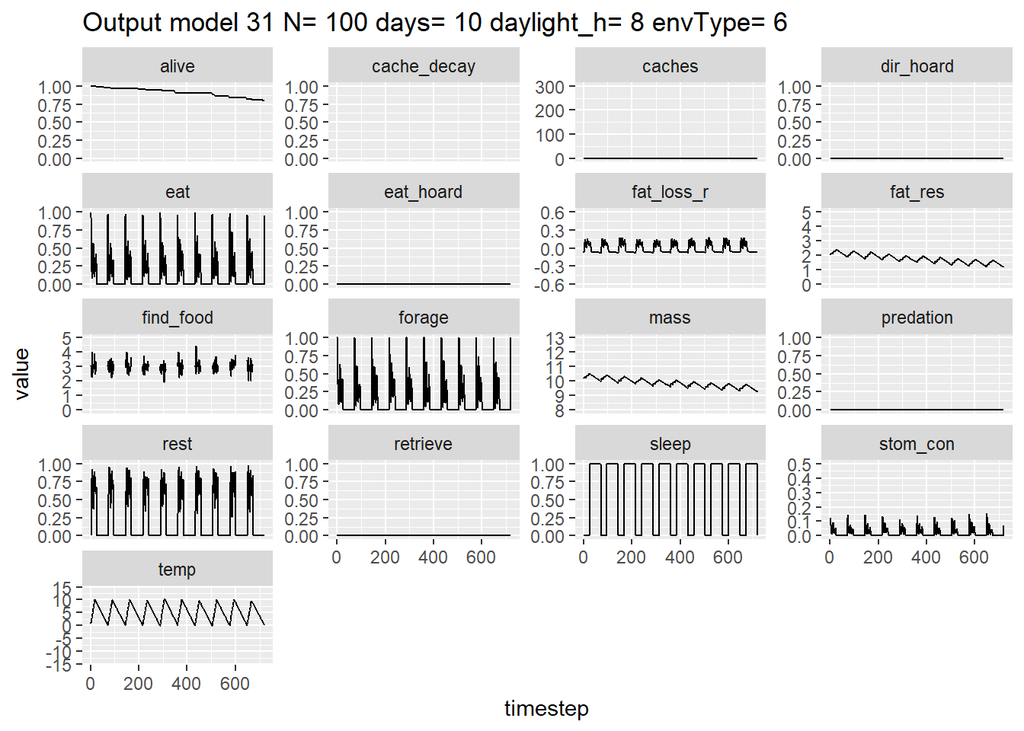

```r
# create plots (standard plots)
plots_12_func(inputdata=save_31_list[[1]], modelType='31')
# if needed
plot_12_31
```

## Run model 3.2: hoarding, FLR, 2 thresholds, 1 variable

```r
#################################################################
##   Model 3.2: Non-hoarding bird, Access to Fat loss rate     ##
#################################################################

  # Run the model (This can take a while)
  mod_3_2(days=days, N=num_birds, env_type = env, th_forage_flr1=0.0244898, th_forage_flr2=0.03265306 , daylight_h = daylight_h)



# list these two
  save_32_list<-list(total_vars_df32, output_df_list_raw32)
  # save the data
  setwd(paste(saving_wd))
  save(save_32_list, file=paste0(format(Sys.time(), "%Y-%m-%d_%H_%M_%S"),'_mod_run32',
                                 'd', days, 'N', N,'env_t', env_type, 'th_flr1', th_forage_flr1,
                                 'th_flr2', th_forage_flr2, 'dayh', daylight_h,   '.Rda'))
# Now you have an Rda object with all the relevant data from your model run.
# It will be marked with the input parameters as well as a time stamp so you can find it and use later :)
```

## Plots for model 3.2: hoarding FLR, 2 thresholds, 1 variable

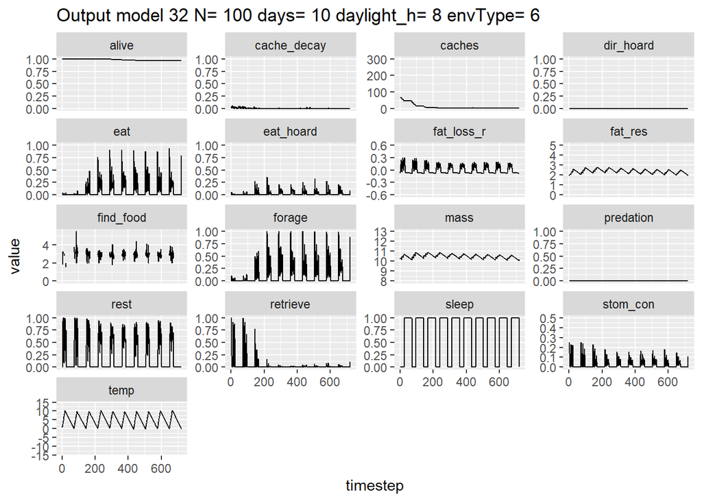

```r
# create plots (standard plots)
plots_12_func(inputdata=save_32_list[[1]], modelType='32')
# if needed
plot_12_32
```

## Run model 4.1: non-hoarding, FR and FLR , 1 threshold for each 2 variables

```r
#################################################################
##   Model 4.1: Non-hoarding bird, Access to FR and FLR        ##
#################################################################

  # Run the model (This can take a while)
  mod_4_1(days=days, N=num_birds, env_type = env, th_forage_fr = 2, th_forage_flr = 0  , daylight_h = daylight_h)

# list these two
  save_41_list<-list(total_vars_df41, output_df_list_raw41)
  # save the data
  setwd(paste(saving_wd))
  save(save_41_list, file=paste0(format(Sys.time(), "%Y-%m-%d_%H_%M_%S"),'_mod_run41',
                                 'd', days, 'N', N,'env_t', env_type, 'th_fr', th_forage_fr ,
                                 'th_flr', th_forage_flr, 'dayh', daylight_h,   '.Rda'))
# Now you have an Rda object with all the relevant data from your model run.
# It will be marked with the input parameters as well as a time stamp so you can find it and use later :)
```

## Plots for model 4.1: non-hoarding FR and FLR, 1 threshold for each of 2 variables

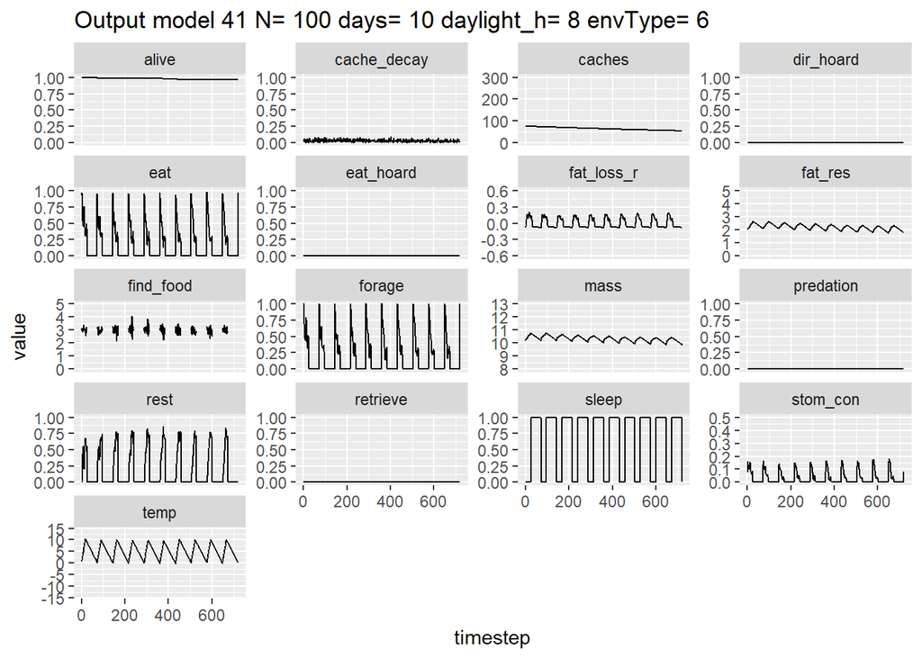

```r
# create plots (standard plots)
plots_12_func(inputdata=save_41_list[[1]], modelType='41')
# if needed
plot_12_41
```

## Run model 4.2: hoarding, FR and FLR , 2 thresholds for each of 2 variables

```r
#################################################################
##   Model 4.2: Non-hoarding bird, Access to FR and FLR        ##
#################################################################

  # Run the model (This can take a while)
  mod_4_2(days=days, N=num_birds, env_type = env, th_forage_fr1=1, th_forage_fr2=2 , th_forage_flr1=-0.3, th_forage_flr2=0.3, daylight_h = daylight_h)

# list these two
  save_42_list<-list(total_vars_df42, output_df_list_raw42)
  # save the data
  setwd(paste(saving_wd))
  save(save_42_list, file=paste0(format(Sys.time(), "%Y-%m-%d_%H_%M_%S"),'_mod_run42',
                                 'd', days, 'N', N,'env_t', env_type, 'th_fr1', th_forage_fr1,
                                 'th_fr2', th_forage_fr2, 'th_flr1', th_forage_flr1, 'th_flr2',
                                 th_forage_flr2, 'dayh', daylight_h,   '.Rda'))
# Now you have an Rda object with all the relevant data from your model run.
# It will be marked with the input parameters as well as a time stamp so you can find it and use later :)
```

## Plots for model 4.2: hoarding FR and FLR , 2 thresholds for each of 2 variables

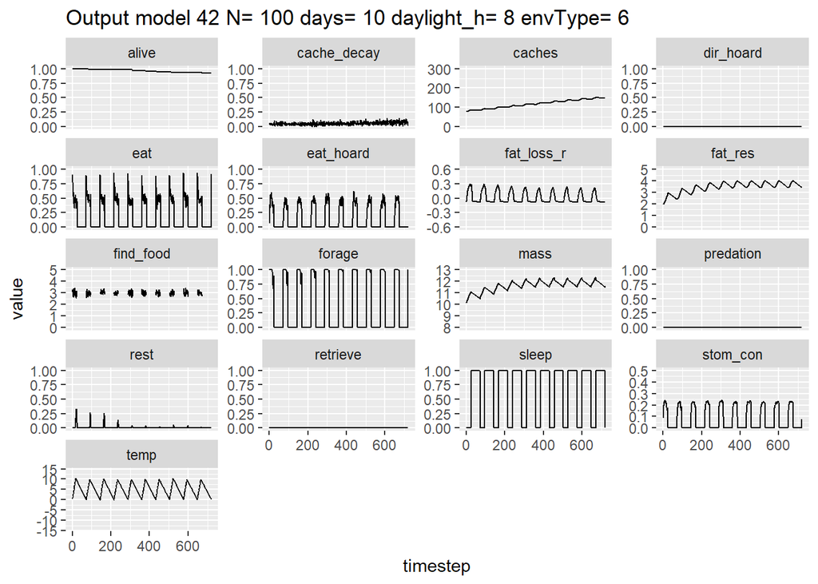

```r
# create plots (standard plots)
plots_12_func(inputdata=save_42_list[[1]], modelType='42')
# if needed
plot_12_42
```

## Run model 5.1: non-hoarding, SC and FR, 1 threshold for each 2 variables

```r
#################################################################
##   Model 5.1: Non-hoarding bird, Access to SC and F R        ##
#################################################################

  # Run the model (This can take a while)
  mod_5_1(days=days, N=num_birds, env_type = env, th_forage_sc = 0.2, th_forage_fr = 2 , daylight_h = daylight_h)

# list these two
  save_51_list<-list(total_vars_df51, output_df_list_raw51)
  # save the data
  setwd(paste(saving_wd))
  save(save_51_list, file=paste0(format(Sys.time(), "%Y-%m-%d_%H_%M_%S"),'_mod_run51',
                                 'd', days, 'N', N,'env_t', env_type, 'th_sc', th_forage_sc ,
                                 'th_fr', th_forage_fr, 'dayh', daylight_h,   '.Rda'))
# Now you have an Rda object with all the relevant data from your model run.
# It will be marked with the input parameters as well as a time stamp so you can find it and use later :)
```

## Plots for model 5.1: non-hoarding SC and FR, 1 threshold for each of 2 variables

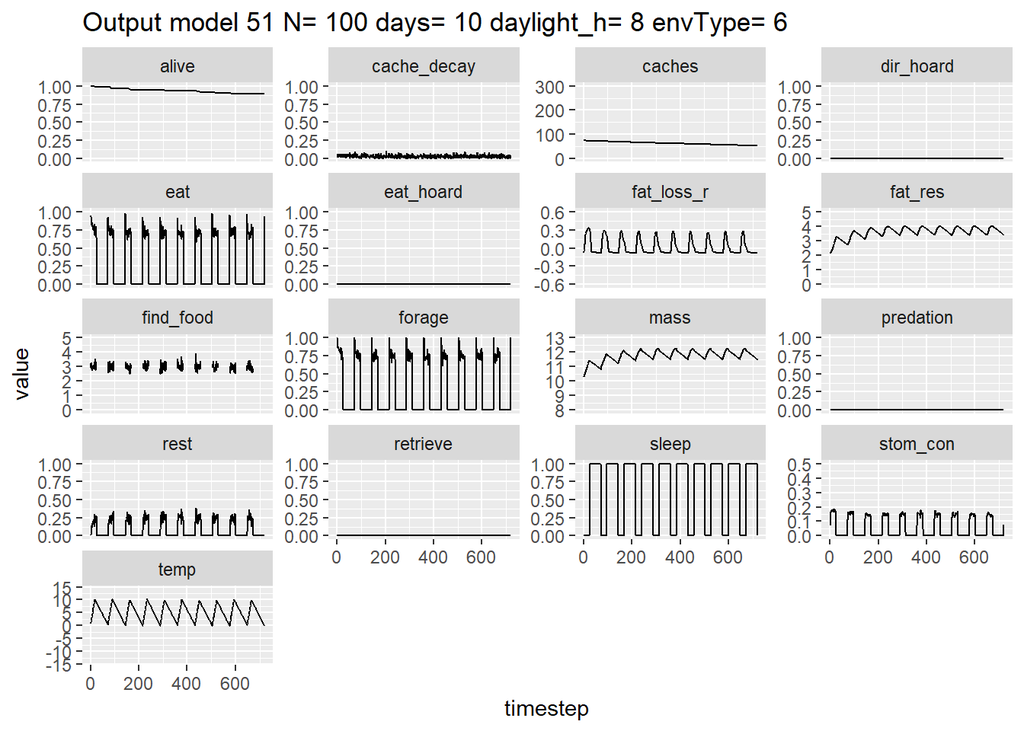

```r
# create plots (standard plots)
plots_12_func(inputdata=save_51_list[[1]], modelType='51')
# if needed
plot_12_51
```

## Run model 5.2: hoarding, SC and FR , 2 thresholds for each of 2 variables

```r
#################################################################
##   Model 5.2: hoarding bird, Access to SC and FR        ##
#################################################################

  # Run the model (This can take a while)
  mod_5_2(days=days, N=num_birds, env_type = env, th_forage_sc1=0.1, th_forage_sc2=0.2 ,
          th_forage_fr1=1, th_forage_fr2=3, daylight_h = daylight_h)

# list these two
  save_52_list<-list(total_vars_df52, output_df_list_raw52)
  # save the data
  setwd(paste(saving_wd))
  save(save_52_list, file=paste0(format(Sys.time(), "%Y-%m-%d_%H_%M_%S"),'_mod_run52',
                                 'd', days, 'N', N,'env_t', env_type, 'th_sc1', th_forage_sc1,
                                 'th_sc2', th_forage_sc2, 'th_fr1', th_forage_fr1, 'th_fr2',
                                 th_forage_fr2, 'dayh', daylight_h,   '.Rda'))
# Now you have an Rda object with all the relevant data from your model run.
# It will be marked with the input parameters as well as a time stamp so you can find it and use later :)
```

## Plots for model 5.2: hoarding SC and FR , 2 thresholds for each of 2 variables

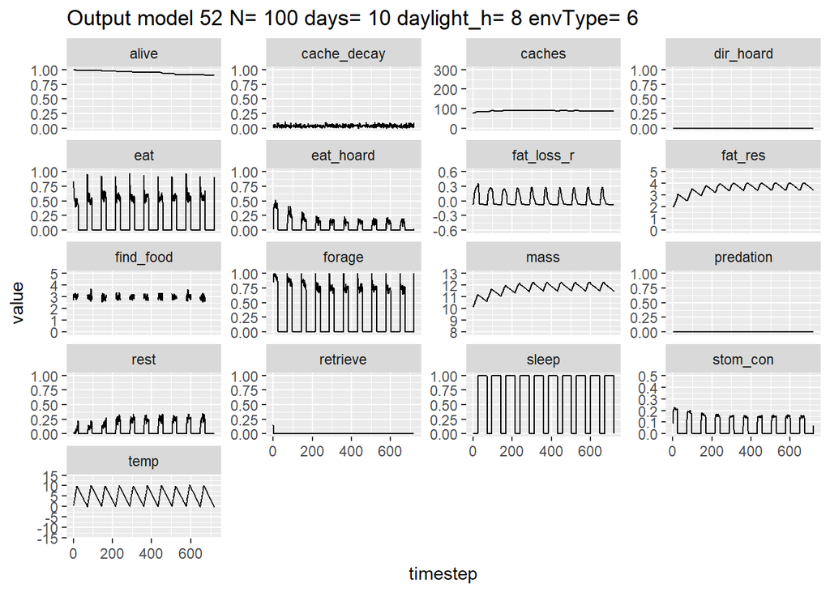

```r
# create plots (standard plots)
plots_12_func(inputdata=save_52_list[[1]], modelType='52')
# if needed
plot_12_52
```

## Run model 6.1: non-hoarding, SC and FLR, 1 threshold for each 2 variables

```r
#################################################################
##   Model 6.1: Non-hoarding bird, Access to SC and FLR        ##
#################################################################

  # Run the model (This can take a while)
  mod_6_1(days=days, N=num_birds, env_type = env, th_forage_sc = 0.2, th_forage_flr = 0 , daylight_h = daylight_h)

# list these two
  save_61_list<-list(total_vars_df61, output_df_list_raw61)
  # save the data
  setwd(paste(saving_wd))
  save(save_61_list, file=paste0(format(Sys.time(), "%Y-%m-%d_%H_%M_%S"),'_mod_run61',
                                 'd', days, 'N', N,'env_t', env_type, 'th_sc', th_forage_sc ,
                                 'th_flr', th_forage_flr, 'dayh', daylight_h,   '.Rda'))
# Now you have an Rda object with all the relevant data from your model run.
# It will be marked with the input parameters as well as a time stamp so you can find it and use later :)
```

## Plots for model 6.1: non-hoarding SC and FLR, 1 threshold for each of 2 variables

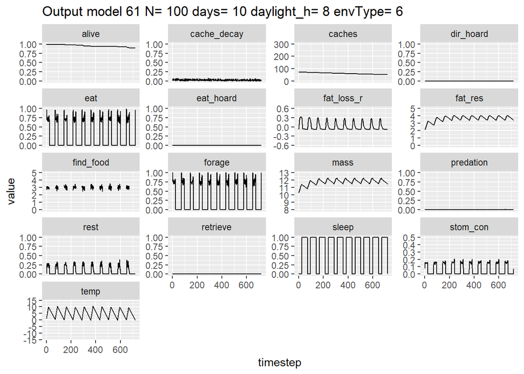

```r
# create plots (standard plots)
plots_12_func(inputdata=save_61_list[[1]], modelType='61')
# if needed
plot_12_61
```

## Run model 6.2: hoarding, SC and FLR , 2 thresholds for each of 2 variables

```r
#################################################################
##   Model 6.2: hoarding bird, Access to SC and FLR           ##
#################################################################

  # Run the model (This can take a while)
  mod_6_2(days=days, N=num_birds, env_type = env, th_forage_sc1=0.1, th_forage_sc2=0.2 ,
          th_forage_flr1=1, th_forage_flr2=3, daylight_h = daylight_h)

# list these two
  save_62_list<-list(total_vars_df62, output_df_list_raw62)
  # save the data
  setwd(paste(saving_wd))
  save(save_62_list, file=paste0(format(Sys.time(), "%Y-%m-%d_%H_%M_%S"),'_mod_run62',
                                 'd', days, 'N', N,'env_t', env_type, 'th_sc1', th_forage_sc1,
                                 'th_sc2', th_forage_sc2, 'th_flr1', th_forage_flr1, 'th_flr2',
                                 th_forage_flr2, 'dayh', daylight_h,   '.Rda'))
# Now you have an Rda object with all the relevant data from your model run.
# It will be marked with the input parameters as well as a time stamp so you can find it and use later :)
```

## Plots for model 6.2: hoarding SC and FLR , 2 thresholds for each of 2 variables

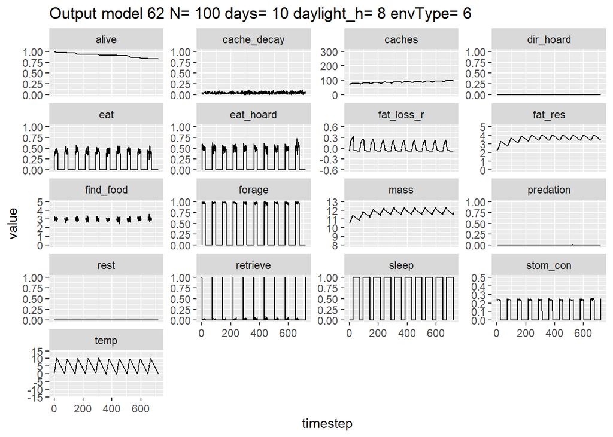

```r
# create plots (standard plots)
plots_12_func(inputdata=save_62_list[[1]], modelType='62')
# if needed
plot_12_62
```